### AFC: Analyse Factorielle des correspondances

On commence par importer nos packages Pandas et NumPy

```python
import pandas as pd
import numpy as np
```

Puis importer nos données et vérifier la taille et leur nature:

```python
df = pd.read_excel("AFC.xlsx", sheet_name=0, header=0, index_col=0)
df
```

| Nationalité/ Année | 2012 | 2013 | 2014 | 2015 | 2016 | 2017 | 2018 | 2019 | 2020 |
| --- | --- | --- | --- | --- | --- | --- | --- | --- | --- |
| Touristes Etrangers | 5011729 | 5323333 | 54374553 | 5151704 | 5103204 | 58644197 | 6679101 | 7043006 | 1407994 |
| France | 1769710 | 1782056 | 1798190 | 1563568 | 1449757 | 1614011 | 1844367 | 1990813 | 412179 |
| Espagne | 730882 | 682834 | 683761 | 626896 | 615720 | 710729 | 814069 | 880818 | 200136 |
| Royaume-Uni | 357347 | 403325 | 476550 | 504475 | 458561 | 486262 | 510516 | 551499 | 113258 |
| Allemange | 199349 | 237852 | 255124 | 286328 | 260255 | 331185 | 394328 | 413384 | 79077 |
| Italie | 196186 | 234912 | 254209 | 227961 | 219334 | 246312 | 305505 | 351916 | 57105 |
| Etats Unis | 140045 | 160033 | 167267 | 181468 | 197858 | 254531 | 304960 | 346702 | 54103 |
| Belgique | 255290 | 272593 | 267308 | 243815 | 238984 | 259658 | 273535 | 272328 | 40603 |
| Hollande | 204767 | 210859 | 191158 | 183349 | 182379 | 214016 | 237539 | 241065 | 40909 |
| Chine | 6899 | 7871 | 9403 | 10515 | 42844 | 107434 | 132081 | 141050 | 20529 |
| Scandinavie | 67165 | 83999 | 95193 | 83554 | 93009 | 118460 | 136157 | 104264 | 22119 |
| MRE | 4363427 | 4722931 | 4845491 | 5025058 | 52285527 | 5484427 | 5609607 | 5889254 | 1369808 |

```python
df.info()
```

```
<class 'pandas.core.frame.DataFrame'>
Index: 12 entries, Touristes Etrangers to MRE
Data columns (total 9 columns):
 #   Column  Non-Null Count  Dtype
---  ------  --------------  -----
 0   2012    12 non-null     int64
 1   2013    12 non-null     int64
 2   2014    12 non-null     int64
 3   2015    12 non-null     int64
 4   2016    12 non-null     int64
 5   2017    12 non-null     int64
 6   2018    12 non-null     int64
 7   2019    12 non-null     int64
 8   2020    12 non-null     int64
dtypes: int64(9)
memory usage: 960.0+ bytes
```

#### Question :

Quelles dont les deux variables étudiées?

- Les variables étudiées sont les nationalités et les années

Maintenant, on va créer les variables I et J contenant le nombre de modalités de chaque variables et les afficher

```python
I = 12
J = 9
print (I, J)
```

```
12 9
```

nous allons créer la variable N contenant le nombre d'individus et l'afficher.

```python
N = sum(df.sum())
N
```

```
273836630
```

On étudie ici 2 variables qualitatives. On va donc faire une analyse factorielle des correspondances. Pour cela on utilise la classe CA du package Fanalysis. Ce package a été développé récemment par Olivier Garcia, il va nous fournir plein de calculs et graphiques clef en main.

```python
import fanalysis
```

Ici les données sont déjà sous forme de tableau de contingence. Sinon, on aurait pu utiliser la fonction "crosstab" sur les données brutes pour extraire ce tableau.

On va transformer notre datafram en tableau

```python
tab = df.values
tab
```

```
array([[ 5011729,  5323333, 54374553,  5151704,  5103204, 58644197,
         6679101,  7043006,  1407994],
       [ 1769710,  1782056,  1798190,  1563568,  1449757,  1614011,
         1844367,  1990813,   412179],
       [  730882,   682834,   683761,   626896,   615720,   710729,
          814069,   880818,   200136],
       [  357347,   403325,   476550,   504475,   458561,   486262,
          510516,   551499,   113258],
       [  199349,   237852,   255124,   286328,   260255,   331185,
          394328,   413384,    79077],
       [  196186,   234912,   254209,   227961,   219334,   246312,
          305505,   351916,    57105],
       [  140045,   160033,   167267,   181468,   197858,   254531,
          304960,   346702,    54103],
       [  255290,   272593,   267308,   243815,   238984,   259658,
          273535,   272328,    40603],
       [  204767,   210859,   191158,   183349,   182379,   214016,
          237539,   241065,    40909],
       [    6899,     7871,     9403,    10515,    42844,   107434,
          132081,   141050,    20529],
       [   67165,    83999,    95193,    83554,    93009,   118460,
          136157,   104264,    22119],
       [ 4363427,  4722931,  4845491,  5025058, 52285527,  5484427,
         5609607,  5889254,  1369808]], dtype=int64)
```

- df = dataframe
- tab = tableau des valeurs

### Test d'indépendance (Khi-deux).

On commence par vérifier si nos variables sont liées, on effectue donc un test d'indépendance ( Khi-deux). On utilise par exemple celui de la librairie scipy. La conction chi2_contingency appliqué à un tableau croisé vas renvoyer 4 informations:

- La valeur de la statistique de test
- La p-valeur
- Le nombre de degré de liberté
- le tableau des effectifs indépendants.

```python
from scipy.stats import chi2_contingency
```

On va faire un test de khi-deux sur df

```python
khi2 = chi2_contingency(df)
khi2
```

```
Chi2ContingencyResult(statistic=151980783.15903112, pvalue=0.0, dof=88, expected_freq=array([[7.22563009e+06, 7.67091888e+06, 3.44466310e+07, 7.65250174e+06,
        3.32132226e+07, 3.71912583e+07, 9.36514519e+06, 9.89980222e+06,
        2.07371105e+06],
       [6.91023807e+05, 7.33609042e+05, 3.29430676e+06, 7.31847717e+05,
        3.17634963e+06, 3.55678945e+06, 8.95636532e+05, 9.46768507e+05,
        1.98319549e+05],
       [2.88845079e+05, 3.06645531e+05, 1.37700653e+06, 3.05909304e+05,
        1.32770095e+06, 1.48672321e+06, 3.74372348e+05, 3.95745301e+05,
        8.28967474e+04],
       [1.87603260e+05, 1.99164553e+05, 8.94358026e+05, 1.98686378e+05,
        8.62334323e+05, 9.65618390e+05, 2.43152742e+05, 2.57034355e+05,
        5.38409728e+04],
       [1.19353645e+05, 1.26708968e+05, 5.68992728e+05, 1.26404752e+05,
        5.48619171e+05, 6.14328744e+05, 1.54694359e+05, 1.63525875e+05,
        3.42537565e+04],
       [1.01697882e+05, 1.07965145e+05, 4.84822689e+05, 1.07705931e+05,
        4.67462954e+05, 5.23452231e+05, 1.31810710e+05, 1.39335796e+05,
        2.91866618e+04],
       [8.77812197e+04, 9.31908508e+04, 4.18478007e+05, 9.29671086e+04,
        4.03493834e+05, 4.51821360e+05, 1.13773312e+05, 1.20268641e+05,
        2.51926660e+04],
       [1.03188004e+05, 1.09547098e+05, 4.91926523e+05, 1.09284086e+05,
        4.74312426e+05, 5.31122083e+05, 1.33742058e+05, 1.41377405e+05,
        2.96143175e+04],
       [8.28783037e+04, 8.79857863e+04, 3.95104414e+05, 8.77745409e+04,
        3.80957164e+05, 4.26585414e+05, 1.07418639e+05, 1.13551179e+05,
        2.37855595e+04],
       [2.32513234e+04, 2.46842162e+04, 1.10845663e+05, 2.46249518e+04,
        1.06876683e+05, 1.19677587e+05, 3.01360596e+04, 3.18565302e+04,
        6.67298570e+03],
       [3.90538832e+04, 4.14606292e+04, 1.86180954e+05, 4.13610862e+04,
        1.79514492e+05, 2.01015419e+05, 5.06177706e+04, 5.35075439e+04,
        1.12082224e+04],
       [4.35248950e+06, 4.62071730e+06, 2.07495537e+07, 4.60962340e+06,
        2.00065878e+07, 2.24028298e+07, 5.64126528e+06, 5.96332565e+06,
        1.24913751e+06]]))
```

Alors:

###### - Le degré de liberté : 88

### L'inertie

Combien vaut l'inertie?

```python
inertie = khi2 [0]/N
inertie
```

```
0.555005307942298
```

### Profils-lignes, profils-colonnes

On va maintenant calculer les profils lignes et colonnes.

- tout d'abord, calculons les effectifs marginaux

```python
year = np.sum(df.values, axis =0)
year
```

```
array([13302796, 14122598, 63418207, 14088691, 61147432, 68471222,
       17241765, 18226099,  3817820], dtype=int64)
```

```python
nationality = np.sum(df.values, axis=1)
nationality
```

```
array([148738821,  14224651,   5945845,   3861793,   2456882,   2093440,
         1806967,   2124114,   1706041,    478626,    803920,  89595530],
      dtype=int64)
```

```python
print (year.shape)
print(nationality.shape)
```

```
(9,)
(12,)
```

Maintenant, nous allons créer à l'aide d'une double boucle for les tableaux des profils lignes "Profil_row" et des profils colonnes "Profil_col"

```python
Profil_col = np.zeros((I,J))
for i in range (I):
     for j in range(J):
         Profil_col[i,j]= tab[i,j]/year[j]
Profil_col
```

```
array([[3.76742528e-01, 3.76937232e-01, 8.57396568e-01, 3.65662360e-01,
        8.34573723e-02, 8.56479486e-01, 3.87379192e-01, 3.86424215e-01,
        3.68795281e-01],
       [1.33032935e-01, 1.26184715e-01, 2.83544756e-02, 1.10980360e-01,
        2.37092050e-02, 2.35721074e-02, 1.06970893e-01, 1.09228695e-01,
        1.07961874e-01],
       [5.49419836e-02, 4.83504522e-02, 1.07817775e-02, 4.44963979e-02,
        1.00694335e-02, 1.03799666e-02, 4.72149458e-02, 4.83272915e-02,
        5.24215390e-02],
       [2.68625483e-02, 2.85588388e-02, 7.51440355e-03, 3.58070881e-02,
        7.49926833e-03, 7.10169887e-03, 2.96092656e-02, 3.02587515e-02,
        2.96656207e-02],
       [1.49854963e-02, 1.68419437e-02, 4.02288258e-03, 2.03232508e-02,
        4.25618855e-03, 4.83684956e-03, 2.28705124e-02, 2.26808820e-02,
        2.07126056e-02],
       [1.47477267e-02, 1.66337667e-02, 4.00845454e-03, 1.61804244e-02,
        3.58696993e-03, 3.59730691e-03, 1.77188936e-02, 1.93083556e-02,
        1.49574888e-02],
       [1.05274861e-02, 1.13316969e-02, 2.63752332e-03, 1.28804017e-02,
        3.23575322e-03, 3.71734274e-03, 1.76872843e-02, 1.90222823e-02,
        1.41711762e-02],
       [1.91907025e-02, 1.93019018e-02, 4.21500406e-03, 1.73057241e-02,
        3.90832439e-03, 3.79222091e-03, 1.58646751e-02, 1.49416504e-02,
        1.06351269e-02],
       [1.53927791e-02, 1.49306098e-02, 3.01424479e-03, 1.30139131e-02,
        2.98261095e-03, 3.12563430e-03, 1.37769538e-02, 1.32263629e-02,
        1.07152773e-02],
       [5.18612779e-04, 5.57333714e-04, 1.48269723e-04, 7.46343291e-04,
        7.00667201e-04, 1.56903874e-03, 7.66052663e-03, 7.73890233e-03,
        5.37715241e-03],
       [5.04893858e-03, 5.94784331e-03, 1.50103581e-03, 5.93057226e-03,
        1.52106142e-03, 1.73006990e-03, 7.89692935e-03, 5.72058782e-03,
        5.79362044e-03],
       [3.28008262e-01, 3.34423666e-01, 7.64053610e-02, 3.56673164e-01,
        8.55073145e-01, 8.00982784e-02, 3.25349928e-01, 3.23122024e-01,
        3.58793238e-01]])
```

```python
profil_row = np.zeros((I,J))
for i in range(I):
    for j in range(J):
        profil_row[i,j]=tab[i,j]/nationality[i]
profil_row
```

```
array([[0.03369483, 0.0357898 , 0.36557069, 0.03463591, 0.03430983,
        0.39427633, 0.04490489, 0.0473515 , 0.00946622],
       [0.12441149, 0.12527942, 0.12641365, 0.1099196 , 0.10191863,
        0.11346577, 0.12965991, 0.13995514, 0.02897639],
       [0.12292315, 0.11484221, 0.11499812, 0.1054343 , 0.10355467,
        0.11953372, 0.13691393, 0.14814009, 0.03365981],
       [0.09253396, 0.10443983, 0.12340123, 0.13063233, 0.11874303,
        0.12591612, 0.13219662, 0.14280905, 0.02932783],
       [0.08113902, 0.09681051, 0.10384056, 0.11654121, 0.10592898,
        0.1347989 , 0.16049936, 0.16825554, 0.03218592],
       [0.09371465, 0.11221339, 0.12143123, 0.10889302, 0.10477205,
        0.11765897, 0.14593444, 0.16810417, 0.02727807],
       [0.0775028 , 0.08856443, 0.09256782, 0.10042685, 0.1094973 ,
        0.1408609 , 0.16876899, 0.19186958, 0.02994133],
       [0.12018658, 0.12833257, 0.12584447, 0.11478433, 0.11250997,
        0.12224297, 0.12877604, 0.12820781, 0.01911526],
       [0.12002467, 0.12359551, 0.11204772, 0.10747045, 0.10690189,
        0.12544599, 0.13923405, 0.14130082, 0.02397891],
       [0.01441418, 0.01644499, 0.01964582, 0.02196914, 0.08951457,
        0.22446336, 0.27595868, 0.29469774, 0.04289153],
       [0.08354687, 0.10448676, 0.11841104, 0.10393323, 0.11569435,
        0.14735297, 0.16936635, 0.1296945 , 0.02751393],
       [0.04870139, 0.05271391, 0.05408184, 0.05608603, 0.58357294,
        0.06121318, 0.06261034, 0.06573156, 0.0152888 ]])
```

On peut vérifier que nos profils somment bien à 1:

```python
print(np.sum(profil_row, axis=1))
print(np.sum(Profil_col, axis=0))
```

```
[1. 1. 1. 1. 1. 1. 1. 1. 1. 1. 1. 1.]
[1. 1. 1. 1. 1. 1. 1. 1. 1.]
```

### Visualisation des Profil-lignes et colonnes

Pour les visualiser, on doit importer la bibliothèque matplotlib

```python
import matplotlib.pyplot as plt
```

```python
df_profil_row = pd.DataFrame(profil_row, index= df.index, columns =df.columns)
df_profil_row
```

| Nationalité/ Année | 2012 | 2013 | 2014 | 2015 | 2016 | 2017 | 2018 | 2019 | 2020 |
| --- | --- | --- | --- | --- | --- | --- | --- | --- | --- |
| Touristes Etrangers | 0.033695 | 0.035790 | 0.365571 | 0.034636 | 0.034310 | 0.394276 | 0.044905 | 0.047351 | 0.009466 |
| France | 0.124411 | 0.125279 | 0.126414 | 0.109920 | 0.101919 | 0.113466 | 0.129660 | 0.139955 | 0.028976 |
| Espagne | 0.122923 | 0.114842 | 0.114998 | 0.105434 | 0.103555 | 0.119534 | 0.136914 | 0.148140 | 0.033660 |
| Royaume-Uni | 0.092534 | 0.104440 | 0.123401 | 0.130632 | 0.118743 | 0.125916 | 0.132197 | 0.142809 | 0.029328 |
| Allemange | 0.081139 | 0.096811 | 0.103841 | 0.116541 | 0.105929 | 0.134799 | 0.160499 | 0.168256 | 0.032186 |
| Italie | 0.093715 | 0.112213 | 0.121431 | 0.108893 | 0.104772 | 0.117659 | 0.145934 | 0.168104 | 0.027278 |
| Etats Unis | 0.077503 | 0.088564 | 0.092568 | 0.100427 | 0.109497 | 0.140861 | 0.168769 | 0.191870 | 0.029941 |
| Belgique | 0.120187 | 0.128333 | 0.125844 | 0.114784 | 0.112510 | 0.122243 | 0.128776 | 0.128208 | 0.019115 |
| Hollande | 0.120025 | 0.123596 | 0.112048 | 0.107470 | 0.106902 | 0.125446 | 0.139234 | 0.141301 | 0.023979 |
| Chine | 0.014414 | 0.016445 | 0.019646 | 0.021969 | 0.089515 | 0.224463 | 0.275959 | 0.294698 | 0.042892 |
| Scandinavie | 0.083547 | 0.104487 | 0.118411 | 0.103933 | 0.115694 | 0.147353 | 0.169366 | 0.129694 | 0.027514 |
| MRE | 0.048701 | 0.052714 | 0.054082 | 0.056086 | 0.583573 | 0.061213 | 0.062610 | 0.065732 | 0.015289 |

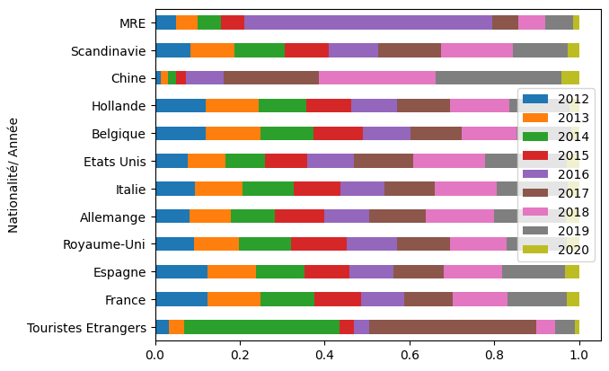

```python
df_profil_row.plot.barh(stacked=True, edgecolor ='none')
```

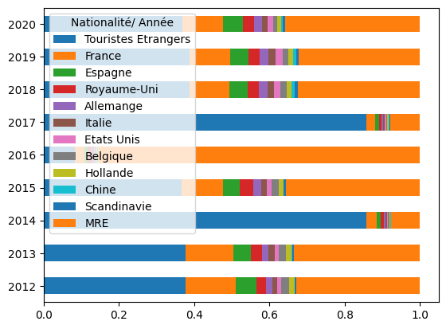

```python
pd.DataFrame(Profil_col.T, index=df.columns, columns=df.index).plot.barh(stacked=True, edgecolor='none')
```

## AFC avec la classe CA

### Instanciation

On crée une instance de la classe CA, en lui précisant les étiquettes des lignes et des colonnes puis on applique le modèle à nos données en utilisant "fit" sur notre tableau. Ce tableau doit etre un tableau de contingence, au format numpy.array.

```python
from fanalysis.ca import CA
```

```python
df_afc = CA(row_labels = df.index.values, col_labels = df.columns.values)
df_afc.fit(tab)
```

```
CA(col_labels=array([2012, 2013, 2014, 2015, 2016, 2017, 2018, 2019, 2020], dtype=int64),
   row_labels=array(['Touristes Etrangers', 'France', 'Espagne', 'Royaume-Uni',
       'Allemange', 'Italie', 'Etats Unis', 'Belgique', 'Hollande',
       'Chine', 'Scandinavie', 'MRE'], dtype=object))
```

#### Explication:

##### Cette méthode df_afc.fit(df.values) contient notamment les attributs suivants:

- df_afc.eig : donne les valeurs propres, les pourcentages d'inertie expliquée et les pourcentages cumulés.
- df_afc.row_coord_ : donne les coordonnées des points lignes selon les axes factoriels
- df_afc.col_coord_ : donne les coordonnées des points colonnes selon les axes factoriels

## Les valeurs propres

```python
df_afc.eig_
```

```
array([[4.60298295e-01, 9.04152075e-02, 3.62000112e-03, 4.52888826e-04,
        1.24464288e-04, 7.32404318e-05, 2.06737629e-05, 5.36836122e-07],
       [8.29358366e+01, 1.62908726e+01, 6.52246216e-01, 8.16008098e-02,
        2.24257833e-02, 1.31963480e-02, 3.72496670e-03, 9.67263041e-05],
       [8.29358366e+01, 9.92267092e+01, 9.98789554e+01, 9.99605562e+01,
        9.99829820e+01, 9.99961783e+01, 9.99999033e+01, 1.00000000e+02]])
```

##### Question: Combien y a-t-il de valeurs propres? Est-ce cohérent?

- 8 valeurs propres.
- le nombre de valeurs propres est égal au minimum entre I-1 et J-1, On n'a J-1 valeurs propres donc c'est cohérent.

##### Question: Combien valent les deux premières valeurs propres?

- Les deux premières valeurs : 4.60298295e-01, 9.04152075e-02

###### cherchons la valeur de l'inertie

```python
Inertie = sum(df_afc.eig_[0])
Inertie
```

```
0.5550053079422976
```

Maintenant, on peut tracer les valeurs propres grace à la fonction "df_afc.plot_eigenvalues()"

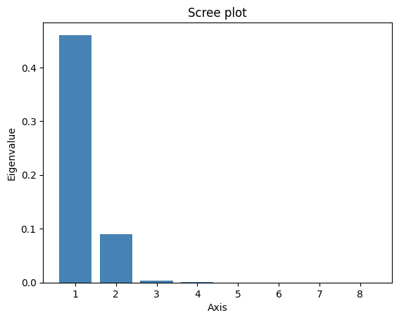

```python
df_afc.plot_eigenvalues()
```

On peut aussi tracer les pourcentages ou les pourcentages cumulés à l'aide des commandes df_afc.plot_eigenvalues(types= "Le type")

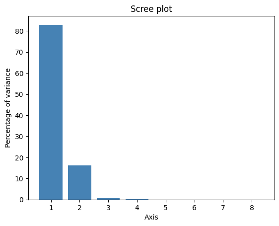

```python
df_afc.plot_eigenvalues(type="percentage")
```

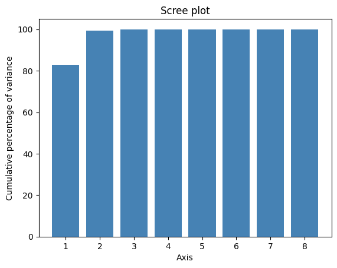

```python
df_afc.plot_eigenvalues(type="cumulative")
```

### Les coordonnées des points lignes et colonnes

Rappellons que l'AFC voit les profils lignes et les profils colonnes comme des points dans un espace à plusieurs dimensions. Le but d'en extraire des représentations graphiques dans un (ou plusieurs) plan factoriel.

```python
df_afc.row_coord_
```

```
array([[-5.81439670e-01,  9.81291595e-02, -4.89081354e-05,
         1.28992795e-04, -4.63100315e-05, -3.33667611e-05,
        -1.98965162e-06,  2.24064519e-06],
       [ 1.19537409e-01, -7.89148190e-01, -9.23940939e-02,
         2.60396438e-02, -1.80395087e-03, -3.96987389e-03,
         5.65970725e-03,  4.01815349e-04],
       [ 1.27606250e-01, -7.95542744e-01, -2.66949098e-02,
         4.72353554e-02, -3.67985682e-02,  1.71577499e-02,
        -6.22293146e-03, -1.18138529e-03],
       [ 1.32480100e-01, -7.23304766e-01,  1.50456774e-02,
        -1.25426632e-01, -2.45351016e-02,  6.21074445e-03,
        -9.39529115e-03, -1.12678432e-03],
       [ 1.25620192e-01, -7.77105651e-01,  1.81859042e-01,
        -8.04119563e-02, -6.55809443e-03,  1.37531638e-02,
         4.60485991e-03,  4.35464622e-03],
       [ 1.23040290e-01, -7.82346257e-01,  8.89043885e-02,
        -3.04719208e-02,  1.55219010e-02, -5.26133274e-02,
         2.73513112e-02, -1.00143349e-03],
       [ 1.34565745e-01, -7.81275889e-01,  2.85312641e-01,
        -1.93801539e-02,  3.45382876e-03, -3.43329284e-02,
        -1.08538757e-02, -1.93319205e-03],
       [ 1.24385170e-01, -7.46606567e-01, -1.21801969e-01,
        -1.12621826e-02,  7.57489757e-02, -9.24080611e-03,
        -2.14974571e-02, -2.95405144e-03],
       [ 1.28440545e-01, -7.82086588e-01, -5.14673985e-02,
         2.71830445e-02,  5.14828044e-02,  2.16898030e-03,
        -2.10116563e-02,  5.34863226e-03],
       [ 8.57661082e-02, -8.11271998e-01,  1.09493803e+00,
         1.98298759e-01,  1.47113679e-02,  1.27114716e-02,
        -9.84513769e-03, -6.86518356e-04],
       [ 1.06898445e-01, -6.99278486e-01,  1.11523779e-01,
        -4.29416217e-02,  8.79256019e-02,  1.07415664e-01,
         3.56570513e-02, -3.25078131e-03],
       [ 9.16253827e-01,  1.44901982e-01,  7.25571876e-05,
         3.06456024e-04, -3.33002022e-05, -2.99903471e-05,
         1.86283987e-05,  3.45218759e-06]])
```

```python
df_afc.col_coord_
```

```
array([[ 1.73954403e-01, -4.83381214e-01, -1.38072734e-01,
         5.02353476e-02, -7.57592489e-03,  3.82020875e-03,
        -8.56339586e-03, -1.00698211e-03],
       [ 1.81261150e-01, -4.61957857e-01, -1.09447105e-01,
         4.77159168e-03,  1.90622594e-02, -5.74551132e-03,
         8.33597720e-03,  1.77481066e-03],
       [-6.19525472e-01,  1.45735298e-01, -2.20926057e-02,
        -2.73526648e-03, -1.87788913e-03, -3.18062165e-03,
         4.43202810e-03, -7.25797284e-04],
       [ 2.19145340e-01, -4.24620730e-01, -5.62550249e-02,
        -7.83656949e-02, -6.20992913e-03,  2.70898534e-03,
        -5.34388405e-03, -2.45804631e-04],
       [ 1.09448210e+00,  2.80759460e-01,  5.78333748e-04,
         1.01673550e-03,  2.64180682e-04, -2.15012808e-04,
         1.48093647e-05, -1.60433074e-05],
       [-6.14301406e-01,  1.54377111e-01,  1.93459816e-02,
         2.67357025e-03,  1.72694239e-03,  2.89684605e-03,
        -4.12521295e-03,  6.69532278e-04],
       [ 1.59594494e-01, -4.59098883e-01,  1.11594791e-01,
         4.96230772e-03,  1.95877788e-02,  1.75973983e-02,
         2.70985353e-03, -8.46623637e-04],
       [ 1.58049436e-01, -4.69455325e-01,  1.15632554e-01,
         8.45993886e-03, -8.98461441e-03, -2.25117138e-02,
        -1.49890437e-03,  4.85503605e-05],
       [ 2.18095118e-01, -4.11661472e-01,  4.83091956e-02,
         1.49021930e-02, -7.07782826e-02,  3.02666872e-02,
         1.37664552e-02,  1.74766855e-03]])
```

On n'a pas besoin de ces fonctions car le package fanalysis nous fournit un outil pour faire la représentation graphique directement (cf ci dessous)

### Contributions et qualités

lors de l'instanciation de l'AFC, d'autres quantités interessantes ont été automatiquement calculées telles que:

- df_afc.row_contrib_ : contributions des profils ( ou modalités) lignes à l'inertie de l'axe
- df_afc.col_contrib_ : contributions des profils (ou modalités) colonnes à l'inertie de l'axe
- df_afc.row_cos2_ : qualités (dites cosinus carrés) des points lignes
- df_afc.col_cos2_ : qualotés (dites cosinus carrés) des points colonnes

Remarque: Si l'on avait souhaité éviter le calcul de ces quantités pour gagner du temps et économiser des ressources mémoire, il aurait fallu préciser "stats_False" en argument de CA.

## Représentations graphiques et interpretations

### 1. Représentations graphiques

On utilise les coordonnées obtenus précédemment pour présenter sur un meme plan nos poinst lignes et colonnes grace à la fonction "mapping".

- On précise en paramètres quels sont les axes que l'on souhaite représenter.
- Si on souhaite afficher que les lignes

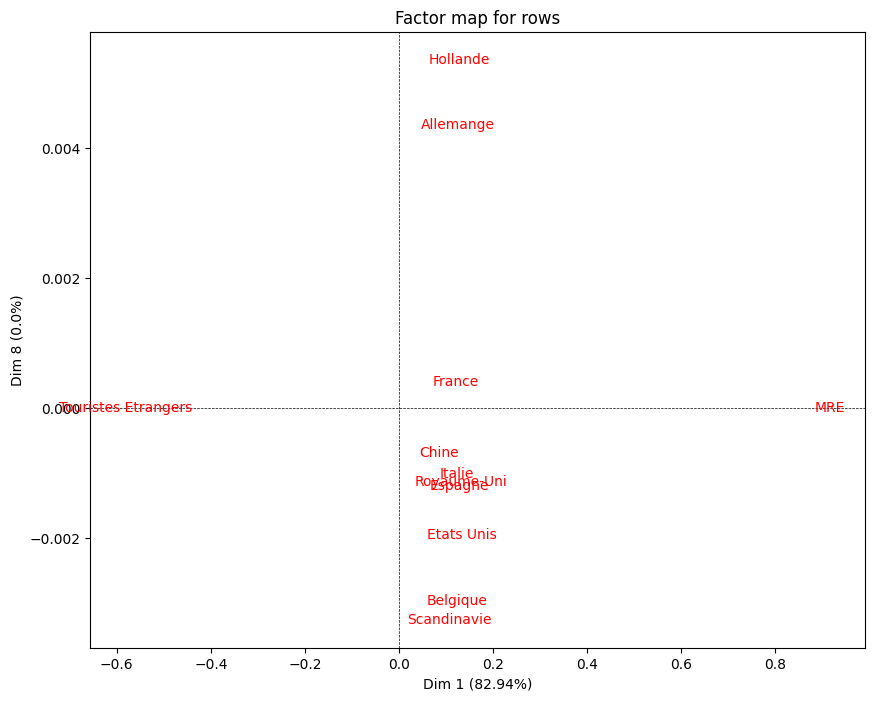

```python
df_afc.mapping_row(num_x_axis=1, num_y_axis=8, figsize=(10, 8))
```

- Si on ne souhaite que les points colonne

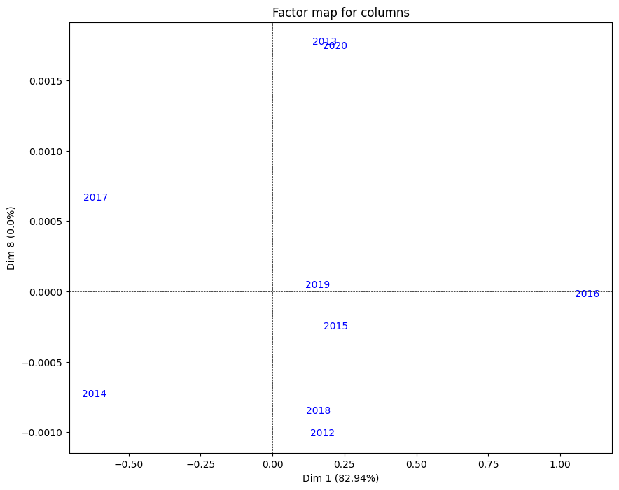

```python
df_afc.mapping_col(num_x_axis=1, num_y_axis=8, figsize=(10, 8))
```

Les deux

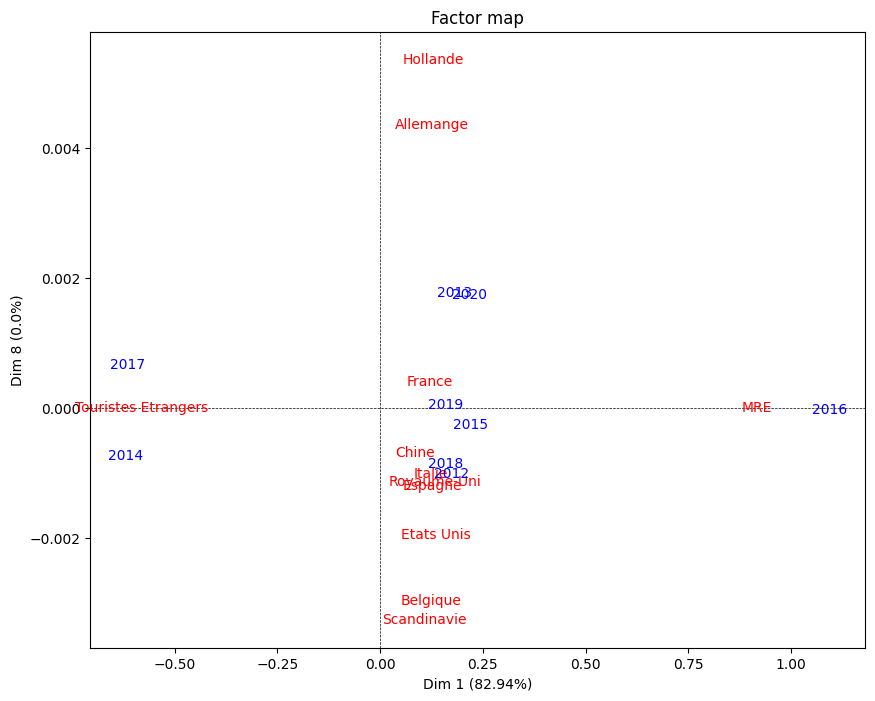

```python
df_afc.mapping(num_x_axis=1, num_y_axis=8, figsize=(10, 8))
```

### 2. Interprétation

Pour interpréter les axes, on va utiliser les qualités et les contributions. Encore une fois, le package fanalysis nous fournit les graphiques dont nous avons besoin sans effort.

- La commande "df_afc.plot_row_contrib" permet de visualiser rapidement les contributions des points lignes au premier axe puis de vérifier leurs qualités de représentations.

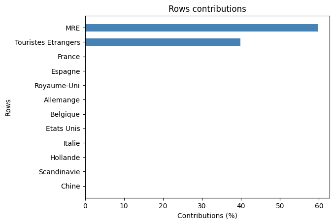

```python
df_afc.plot_row_contrib(num_axis=1)
```

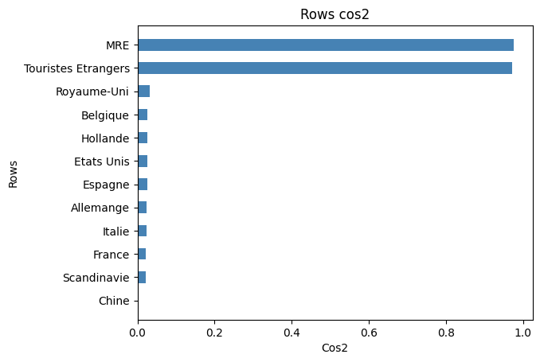

```python
df_afc.plot_row_cos2(num_axis=1)
```

- Contributions des points colonnes au premier axe, et leurs qualités.

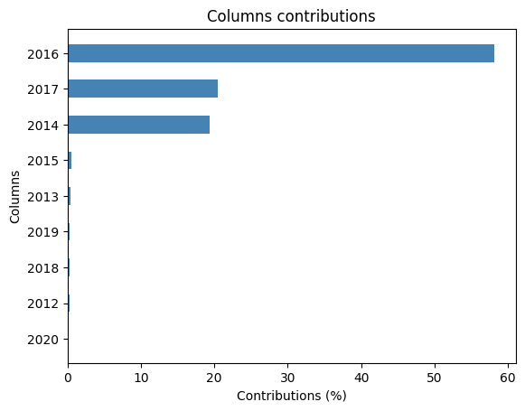

```python
df_afc.plot_col_contrib(num_axis=1)
```

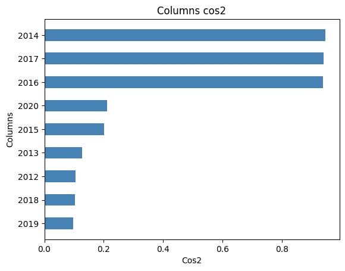

```python
df_afc.plot_col_cos2(num_axis=1)
```

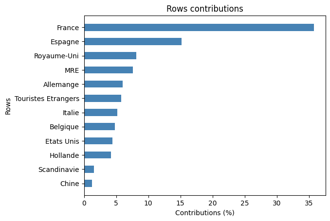

```python
df_afc.plot_row_contrib(num_axis=2)
```

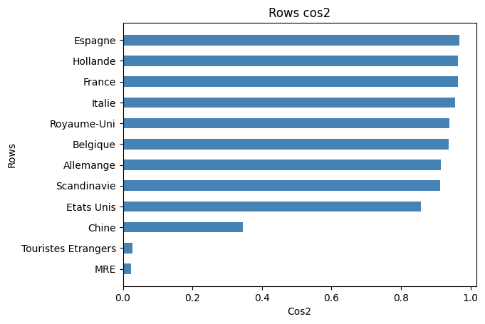

```python
df_afc.plot_row_cos2(num_axis=2)
```

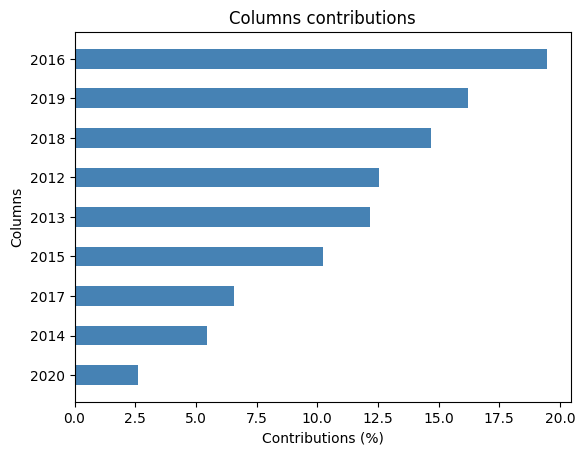

```python
df_afc.plot_col_contrib(num_axis=2)
```